# MNIST classification (20 marks):

1a) In the file mnist.py identify where the Stochastic Gradient Descent optimizer is created. Train the default CNN architecture by choosing appropriate parameter values for: i) Learning rate – explain what happens when you use too large or too small value and explain why it is happening. ii) Weight decay – explain what happens when you use too large or too small regularization and explain why it is happening.

```python
from __future__ import print_function
import torch
import torch.nn as nn
import torch.nn.functional as F
import torch.optim as optim
from torchvision import datasets, transforms
import matplotlib.pyplot as plt
%matplotlib inline

# Training hyperparameters
epochs = 3
batch_size = 64
learning_rate = 0.09 # TODO
momentum = 0.9
weight_decay = 0.02 # TODO
log_interval = 20

class CNN(nn.Module):
    def __init__(self):
        super(CNN, self).__init__()
        self.conv1 = nn.Conv2d(in_channels=1, out_channels=16,
                               kernel_size=5, stride=1, padding=0)
        self.maxpool = nn.MaxPool2d(2)
        self.conv2 = nn.Conv2d(in_channels=16, out_channels=32,
                               kernel_size=3, stride=1, padding=0)
        self.fc1 = nn.Linear(in_features=800, out_features=128)
        self.fc2 = nn.Linear(in_features=128, out_features=10)

        nn.init.kaiming_normal_(self.conv1.weight, nonlinearity='relu')
        nn.init.kaiming_normal_(self.conv2.weight, nonlinearity='relu')
        nn.init.kaiming_normal_(self.fc1.weight, nonlinearity='relu')
        nn.init.kaiming_normal_(self.fc2.weight, nonlinearity='linear')

    def forward(self, x):
        x = self.conv1(x)
        x = F.relu(x)
        x = self.maxpool(x)
        x = self.conv2(x)
        x = F.relu(x)
        x = self.maxpool(x)
        x = x.view(-1, 800)
        x = self.fc1(x)
        x = F.relu(x)
        x = self.fc2(x)
        return F.log_softmax(x, dim=1)

class CNN2(nn.Module):
    def __init__(self):
        super(CNN2, self).__init__()
        self.conv1 = nn.Conv2d(in_channels=1, out_channels=32,
                               kernel_size=5, stride=1, padding=2)
        self.maxpool = nn.MaxPool2d(2)
        self.conv2 = nn.Conv2d(in_channels=32, out_channels=64,
                               kernel_size=5, stride=1, padding=2)
        self.fc1 = nn.Linear(in_features=3136, out_features=256)
        self.fc2 = nn.Linear(in_features=256, out_features=10)

        nn.init.kaiming_normal_(self.conv1.weight, nonlinearity='relu')
        nn.init.kaiming_normal_(self.conv2.weight, nonlinearity='relu')
        nn.init.kaiming_normal_(self.fc1.weight, nonlinearity='relu')
        nn.init.kaiming_normal_(self.fc2.weight, nonlinearity='linear')

    def forward(self, x):
        x = self.conv1(x)
        x = F.relu(x)
        x = self.maxpool(x)
        x = self.conv2(x)
        x = F.relu(x)
        x = self.maxpool(x)
        x = x.view(-1, 3136)
        x = self.fc1(x)
        x = F.relu(x)
        x = self.fc2(x)
        return F.log_softmax(x, dim=1)


class CNN3(nn.Module):
    def __init__(self):
        super(CNN3, self).__init__()
        self.conv1 = nn.Conv2d(in_channels=1, out_channels=32,
                               kernel_size=5, stride=1, padding=2)
        self.maxpool = nn.MaxPool2d(2)
        self.conv2 = nn.Conv2d(in_channels=32, out_channels=64,
                               kernel_size=5, stride=1, padding=2)
        self.fc1 = nn.Linear(in_features=3136, out_features=256)
        self.fc2 = nn.Linear(in_features=256, out_features=10)
        self.dropout = nn.Dropout(0.2)

        nn.init.kaiming_normal_(self.conv1.weight, nonlinearity='relu')
        nn.init.kaiming_normal_(self.conv2.weight, nonlinearity='relu')
        nn.init.kaiming_normal_(self.fc1.weight, nonlinearity='relu')
        nn.init.kaiming_normal_(self.fc2.weight, nonlinearity='linear')


    def forward(self, x):
        x = self.conv1(x)
        x = F.relu(x)
        x = self.maxpool(x)
        x = self.conv2(x)
        x = F.relu(x)
        x = self.maxpool(x)
        x = self.dropout(x)
        x = x.view(-1, 3136)
        x = self.fc1(x)
        x = F.relu(x)
        x = self.dropout(x)
        x = self.fc2(x)
        return F.log_softmax(x, dim=1)

class CNN4(nn.Module):
    def __init__(self):
        super(CNN4, self).__init__()
        self.conv1 = nn.Conv2d(in_channels=3, out_channels=24,
                               kernel_size=9, stride=1, padding=2)

        self.conv2 = nn.Conv2d(in_channels=24, out_channels=40,
                               kernel_size=3, stride=1, padding=2)
        self.maxpool1 = nn.MaxPool2d(2)
        self.conv3 = nn.Conv2d(in_channels=40, out_channels=80,
                                kernel_size=3, stride=1, padding=2)
        self.maxpool2 = nn.MaxPool2d(4)
        self.fc1 = nn.Linear(in_features=1280, out_features=224)
        self.fc2 = nn.Linear(in_features=224, out_features=10)

        nn.init.kaiming_normal_(self.conv1.weight, nonlinearity='relu')
        nn.init.kaiming_normal_(self.conv2.weight, nonlinearity='relu')
        nn.init.kaiming_normal_(self.fc1.weight, nonlinearity='relu')
        nn.init.kaiming_normal_(self.fc2.weight, nonlinearity='linear')

    def forward(self, x):
        x = self.conv1(x)
        x = F.relu(x)
        x = self.conv2(x)
        x = F.relu(x)
        x = self.maxpool1(x)
        x = self.conv3(x)
        x = F.relu(x)
        x = self.maxpool2(x)
        x = x.view(-1, 1280)
        x = self.fc1(x)
        x = F.relu(x)
        x = self.fc2(x)
        return F.log_softmax(x, dim=1)



def plot_data(data, label, text):
    fig = plt.figure()
    for i in range(6):
        plt.subplot(2,3,i+1)
        plt.tight_layout()
        plt.imshow(data[i][0], cmap='gray', interpolation='none')
        plt.title(text + ": {}".format(label[i]))
        plt.xticks([])
        plt.yticks([])
    plt.show()

def predict_batch(model, device, test_loader):
    examples = enumerate(test_loader)
    model.eval()
    with torch.no_grad():
        batch_idx, (data, target) = next(examples)
        data, target = data.to(device), target.to(device)
        output = model(data)
        pred = output.cpu().data.max(1, keepdim=True)[1] # get the index of the max log-probability
        pred = pred.numpy()
    return data.cpu().data.numpy(), target.cpu().data.numpy(), pred

def plot_graph(train_x, train_y, test_x, test_y, ylabel=''):
    fig = plt.figure()
    plt.plot(train_x, train_y, color='blue')
    plt.plot(test_x, test_y, color='red')
    plt.legend(['Train', 'Test'], loc='upper right')
    plt.xlabel('number of training examples seen')
    plt.ylabel(ylabel)
    plt.grid()
    plt.show()
```

```python
def train(model, device, train_loader, optimizer, epoch, losses=[], counter=[], errors=[]):
    model.train()
    correct=0
    for batch_idx, (data, target) in enumerate(train_loader):
        data, target = data.to(device), target.to(device)
        optimizer.zero_grad()
        output = model(data)
        loss = F.nll_loss(output, target)
        loss.backward()
        optimizer.step()
        if batch_idx % log_interval == 0:
            print('Train Epoch: {} [{}/{} ({:.0f}%)]\tLoss: {:.6f}'.format(
                epoch, batch_idx * len(data), len(train_loader.dataset),
                100. * batch_idx / len(train_loader), loss.item()))
            losses.append(loss.item())
            counter.append((batch_idx*batch_size) + ((epoch-1)*len(train_loader.dataset)))
        pred = output.max(1, keepdim=True)[1]
        correct += pred.eq(target.view_as(pred)).sum().item()
    errors.append(100. * (1 - correct / len(train_loader.dataset)))

def test(model, device, test_loader, losses=[], errors=[]):
    model.eval()
    test_loss = 0
    correct = 0
    with torch.no_grad():
        for data, target in test_loader:
            data, target = data.to(device), target.to(device)
            output = model(data)
            test_loss += F.nll_loss(output, target, reduction='sum').item() # sum up batch loss
            pred = output.max(1, keepdim=True)[1] # get the index of the max log-probability
            correct += pred.eq(target.view_as(pred)).sum().item()

    test_loss /= len(test_loader.dataset)
    print('\nTest set: Average loss: {:.4f}, Accuracy: {}/{} ({:.0f}%)\n'.format(
        test_loss, correct, len(test_loader.dataset),
        100. * correct / len(test_loader.dataset)))
    losses.append(test_loss)
    errors.append(100. *  (1 - correct / len(test_loader.dataset)))

def calculate_mean_std(dataset):
    mean = 0.0
    for img, _  in dataset:
        mean += img.mean([1,2])
    mean = mean/len(dataset)
    print('images mean {}'.format(mean))

    std = 0.0
    for img, _  in dataset:
        std += torch.mean(img - mean)**2
    std = torch.sqrt(std/len(dataset))
    print('images std {}'.format(std))

    return mean, std

def cifar_loader(use_cuda=False):
    # data transformation
    train_data = datasets.CIFAR10('../data', train=True, download=True,
                   transform=transforms.Compose([
                       transforms.ToTensor()
                   ]))
    test_data = datasets.CIFAR10('../data', train=False,
                   transform=transforms.Compose([
                       transforms.ToTensor()
                   ]))

    # data loaders
    kwargs = {'num_workers': 1, 'pin_memory': True} if use_cuda else {}
    train_loader = torch.utils.data.DataLoader(train_data, batch_size=batch_size, shuffle=True, **kwargs)
    test_loader = torch.utils.data.DataLoader(test_data, batch_size=batch_size, shuffle=False, **kwargs)

    return train_loader, test_loader

def mnist_loader(use_cuda=False):
    # data transformation
    train_data = datasets.MNIST('../data', train=True, download=True,
                   transform=transforms.Compose([
                       transforms.ToTensor(),
                       transforms.Normalize((0.1307,), (0.3081,))
                   ]))
    test_data = datasets.MNIST('../data', train=False,
                   transform=transforms.Compose([
                       transforms.ToTensor(),
                       transforms.Normalize((0.1307,), (0.3081,))
                   ]))

    # data loaders
    kwargs = {'num_workers': 1, 'pin_memory': True} if use_cuda else {}
    train_loader = torch.utils.data.DataLoader(train_data, batch_size=batch_size, shuffle=True, **kwargs)
    test_loader = torch.utils.data.DataLoader(test_data, batch_size=batch_size, shuffle=False, **kwargs)

    return train_loader, test_loader

def fashionmnist_loader(use_cuda=False):
    # data transformation
    train_data = datasets.FashionMNIST('../data', train=True, download=True,
                   transform=transforms.Compose([
                       transforms.ToTensor()
                   ]))
    test_data = datasets.FashionMNIST('../data', train=False,
                   transform=transforms.Compose([
                       transforms.ToTensor()
                   ]))

    mean_train, std_train = calculate_mean_std(train_data)
    mean_test, std_test = calculate_mean_std(test_data)

    train_data.transform = transforms.Compose([
        transforms.ToTensor(),
        transforms.Normalize((mean_train,), (std_train,))
    ])

    test_data.transform = transforms.Compose([
        transforms.ToTensor(),
        transforms.Normalize((mean_test,), (std_test,))
    ])

    # data loaders
    kwargs = {'num_workers': 1, 'pin_memory': True} if use_cuda else {}
    train_loader = torch.utils.data.DataLoader(train_data, batch_size=batch_size, shuffle=True, **kwargs)
    test_loader = torch.utils.data.DataLoader(test_data, batch_size=batch_size, shuffle=False, **kwargs)

    return train_loader, test_loader

def profile_model(model):
    from thop import profile
    input = torch.randn(1,3,32,32)
    flops, params = profile(model, inputs=(input,))
    print('flops {} params count {}'.format(flops, params))

    parameter_count = 0
    for parameter in model.parameters():
        nn = 1
        for s in list(parameter.size()):
            nn *= s
        parameter_count += nn

    print('params count {}'.format(parameter_count))


def main():
    use_cuda = torch.cuda.is_available()
    device = torch.device("cuda" if use_cuda else "cpu")

   # train_loader, test_loader = fashionmnist_loader(use_cuda)
    train_loader, test_loader = mnist_loader(use_cuda)

	# extract and plot random samples of data
    #examples = enumerate(test_loader)
    #batch_idx, (data, target) = next(examples)
    #plot_data(data, target, 'Ground truth')

    # model creation
    model = CNN().to(device)
    # profile_model(model)
    # optimizer creation
    optimizer = optim.SGD(model.parameters(), lr=learning_rate, momentum=momentum, weight_decay=weight_decay)
```

```
Test set: Average loss: 4.5074, Accuracy: 625/10000 (6%)

Train Epoch: 1 [0/60000 (0%)]	Loss: 4.573420
Train Epoch: 1 [1280/60000 (2%)]	Loss: 2.307992
Train Epoch: 1 [2560/60000 (4%)]	Loss: 1.851973
Train Epoch: 1 [3840/60000 (6%)]	Loss: 1.288723
Train Epoch: 1 [5120/60000 (9%)]	Loss: 0.955606
Train Epoch: 1 [6400/60000 (11%)]	Loss: 0.821233
Train Epoch: 1 [7680/60000 (13%)]	Loss: 0.618452
Train Epoch: 1 [8960/60000 (15%)]	Loss: 0.699783
Train Epoch: 1 [10240/60000 (17%)]	Loss: 0.717506
Train Epoch: 1 [11520/60000 (19%)]	Loss: 0.772485
Train Epoch: 1 [12800/60000 (21%)]	Loss: 0.300110
Train Epoch: 1 [14080/60000 (23%)]	Loss: 0.778736
Train Epoch: 1 [15360/60000 (26%)]	Loss: 0.893156
Train Epoch: 1 [16640/60000 (28%)]	Loss: 0.716961
Train Epoch: 1 [17920/60000 (30%)]	Loss: 0.838538
Train Epoch: 1 [19200/60000 (32%)]	Loss: 0.620455
Train Epoch: 1 [20480/60000 (34%)]	Loss: 0.449628
Train Epoch: 1 [21760/60000 (36%)]	Loss: 0.386485
Train Epoch: 1 [23040/60000 (38%)]	Loss: 0.470938
Train Epoch: 1 [24320/60000 (41%)]	Loss: 0.482020
Train Epoch: 1 [25600/60000 (43%)]	Loss: 0.421959
Train Epoch: 1 [26880/60000 (45%)]	Loss: 0.482717
Train Epoch: 1 [28160/60000 (47%)]	Loss: 0.544186
Train Epoch: 1 [29440/60000 (49%)]	Loss: 0.822258
Train Epoch: 1 [30720/60000 (51%)]	Loss: 0.445020
Train Epoch: 1 [32000/60000 (53%)]	Loss: 0.492305
Train Epoch: 1 [33280/60000 (55%)]	Loss: 0.678837
Train Epoch: 1 [34560/60000 (58%)]	Loss: 0.729390
Train Epoch: 1 [35840/60000 (60%)]	Loss: 0.618305
Train Epoch: 1 [37120/60000 (62%)]	Loss: 0.785043
Train Epoch: 1 [38400/60000 (64%)]	Loss: 0.514722
Train Epoch: 1 [39680/60000 (66%)]	Loss: 0.774148
Train Epoch: 1 [40960/60000 (68%)]	Loss: 0.314536
Train Epoch: 1 [42240/60000 (70%)]	Loss: 0.747002
Train Epoch: 1 [43520/60000 (72%)]	Loss: 0.431266
Train Epoch: 1 [44800/60000 (75%)]	Loss: 0.407664
Train Epoch: 1 [46080/60000 (77%)]	Loss: 0.175567
Train Epoch: 1 [47360/60000 (79%)]	Loss: 0.575364
```

[output cut: 96 more lines]

```
Train Epoch: 3 [43520/60000 (72%)]	Loss: 0.362493
Train Epoch: 3 [44800/60000 (75%)]	Loss: 0.496814
Train Epoch: 3 [46080/60000 (77%)]	Loss: 0.301570
Train Epoch: 3 [47360/60000 (79%)]	Loss: 0.698526
Train Epoch: 3 [48640/60000 (81%)]	Loss: 0.499834
Train Epoch: 3 [49920/60000 (83%)]	Loss: 0.367390
Train Epoch: 3 [51200/60000 (85%)]	Loss: 0.398312
Train Epoch: 3 [52480/60000 (87%)]	Loss: 0.536734
Train Epoch: 3 [53760/60000 (90%)]	Loss: 0.270732
Train Epoch: 3 [55040/60000 (92%)]	Loss: 0.400225
Train Epoch: 3 [56320/60000 (94%)]	Loss: 0.549320
Train Epoch: 3 [57600/60000 (96%)]	Loss: 0.395413
Train Epoch: 3 [58880/60000 (98%)]	Loss: 0.754094

Test set: Average loss: 0.5183, Accuracy: 8340/10000 (83%)
```

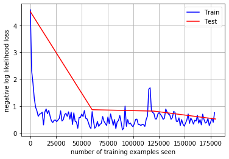

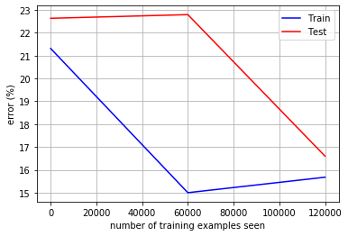

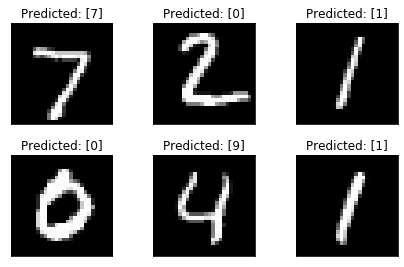

```python
    # lists for saving history
    train_losses = []
    train_counter = []
    test_losses = []
    test_counter = [i*len(train_loader.dataset) for i in range(epochs + 1)]
    train_errors = []
    test_errors = []
    error_counter = [i*len(train_loader.dataset) for i in range(epochs)]

    # test of randomly initialized model
    test(model, device, test_loader, losses=test_losses)

    # global training and testing loop
    for epoch in range(1, epochs + 1):
        train(model, device, train_loader, optimizer, epoch, losses=train_losses, counter=train_counter, errors=train_errors)
        test(model, device, test_loader, losses=test_losses, errors=test_errors)

    # plotting training history
    plot_graph(train_counter, train_losses, test_counter, test_losses, ylabel='negative log likelihood loss')
    plot_graph(error_counter, train_errors, error_counter, test_errors, ylabel='error (%)')

    # extract and plot random samples of data with predicted labels
    data, _, pred = predict_batch(model, device, test_loader)
    plot_data(data, pred, 'Predicted')

if __name__ == '__main__':
    main()
```

# with learning rate=0.02 and weight decay = .002

```python
from __future__ import print_function
import torch
import torch.nn as nn
import torch.nn.functional as F
import torch.optim as optim
from torchvision import datasets, transforms
import matplotlib.pyplot as plt
%matplotlib inline

# Training hyperparameters
epochs = 3
batch_size = 64
learning_rate = 0.02 # TODO
momentum = 0.9
weight_decay = 0.002 # TODO
log_interval = 20

class CNN(nn.Module):
    def __init__(self):
        super(CNN, self).__init__()
        self.conv1 = nn.Conv2d(in_channels=1, out_channels=16,
                               kernel_size=5, stride=1, padding=0)
        self.maxpool = nn.MaxPool2d(2)
        self.conv2 = nn.Conv2d(in_channels=16, out_channels=32,
                               kernel_size=3, stride=1, padding=0)
        self.fc1 = nn.Linear(in_features=800, out_features=128)
        self.fc2 = nn.Linear(in_features=128, out_features=10)

        nn.init.kaiming_normal_(self.conv1.weight, nonlinearity='relu')
        nn.init.kaiming_normal_(self.conv2.weight, nonlinearity='relu')
        nn.init.kaiming_normal_(self.fc1.weight, nonlinearity='relu')
        nn.init.kaiming_normal_(self.fc2.weight, nonlinearity='linear')

    def forward(self, x):
        x = self.conv1(x)
        x = F.relu(x)
        x = self.maxpool(x)
        x = self.conv2(x)
        x = F.relu(x)
        x = self.maxpool(x)
        x = x.view(-1, 800)
        x = self.fc1(x)
        x = F.relu(x)
        x = self.fc2(x)
        return F.log_softmax(x, dim=1)

class CNN2(nn.Module):
    def __init__(self):
        super(CNN2, self).__init__()
        self.conv1 = nn.Conv2d(in_channels=1, out_channels=32,
                               kernel_size=5, stride=1, padding=2)
        self.maxpool = nn.MaxPool2d(2)
        self.conv2 = nn.Conv2d(in_channels=32, out_channels=64,
                               kernel_size=5, stride=1, padding=2)
        self.fc1 = nn.Linear(in_features=3136, out_features=256)
        self.fc2 = nn.Linear(in_features=256, out_features=10)

        nn.init.kaiming_normal_(self.conv1.weight, nonlinearity='relu')
        nn.init.kaiming_normal_(self.conv2.weight, nonlinearity='relu')
        nn.init.kaiming_normal_(self.fc1.weight, nonlinearity='relu')
        nn.init.kaiming_normal_(self.fc2.weight, nonlinearity='linear')

    def forward(self, x):
        x = self.conv1(x)
        x = F.relu(x)
        x = self.maxpool(x)
        x = self.conv2(x)
        x = F.relu(x)
        x = self.maxpool(x)
        x = x.view(-1, 3136)
        x = self.fc1(x)
        x = F.relu(x)
        x = self.fc2(x)
        return F.log_softmax(x, dim=1)


class CNN3(nn.Module):
    def __init__(self):
        super(CNN3, self).__init__()
        self.conv1 = nn.Conv2d(in_channels=1, out_channels=32,
                               kernel_size=5, stride=1, padding=2)
        self.maxpool = nn.MaxPool2d(2)
        self.conv2 = nn.Conv2d(in_channels=32, out_channels=64,
                               kernel_size=5, stride=1, padding=2)
        self.fc1 = nn.Linear(in_features=3136, out_features=256)
        self.fc2 = nn.Linear(in_features=256, out_features=10)
        self.dropout = nn.Dropout(0.2)

        nn.init.kaiming_normal_(self.conv1.weight, nonlinearity='relu')
        nn.init.kaiming_normal_(self.conv2.weight, nonlinearity='relu')
        nn.init.kaiming_normal_(self.fc1.weight, nonlinearity='relu')
        nn.init.kaiming_normal_(self.fc2.weight, nonlinearity='linear')


    def forward(self, x):
        x = self.conv1(x)
        x = F.relu(x)
        x = self.maxpool(x)
        x = self.conv2(x)
        x = F.relu(x)
        x = self.maxpool(x)
        x = self.dropout(x)
        x = x.view(-1, 3136)
        x = self.fc1(x)
        x = F.relu(x)
        x = self.dropout(x)
        x = self.fc2(x)
        return F.log_softmax(x, dim=1)

class CNN4(nn.Module):
    def __init__(self):
        super(CNN4, self).__init__()
        self.conv1 = nn.Conv2d(in_channels=3, out_channels=24,
                               kernel_size=9, stride=1, padding=2)

        self.conv2 = nn.Conv2d(in_channels=24, out_channels=40,
                               kernel_size=3, stride=1, padding=2)
        self.maxpool1 = nn.MaxPool2d(2)
        self.conv3 = nn.Conv2d(in_channels=40, out_channels=80,
                                kernel_size=3, stride=1, padding=2)
        self.maxpool2 = nn.MaxPool2d(4)
        self.fc1 = nn.Linear(in_features=1280, out_features=224)
        self.fc2 = nn.Linear(in_features=224, out_features=10)

        nn.init.kaiming_normal_(self.conv1.weight, nonlinearity='relu')
        nn.init.kaiming_normal_(self.conv2.weight, nonlinearity='relu')
        nn.init.kaiming_normal_(self.fc1.weight, nonlinearity='relu')
        nn.init.kaiming_normal_(self.fc2.weight, nonlinearity='linear')

    def forward(self, x):
        x = self.conv1(x)
        x = F.relu(x)
        x = self.conv2(x)
        x = F.relu(x)
        x = self.maxpool1(x)
        x = self.conv3(x)
        x = F.relu(x)
        x = self.maxpool2(x)
        x = x.view(-1, 1280)
        x = self.fc1(x)
        x = F.relu(x)
        x = self.fc2(x)
        return F.log_softmax(x, dim=1)



def plot_data(data, label, text):
    fig = plt.figure()
    for i in range(6):
        plt.subplot(2,3,i+1)
        plt.tight_layout()
        plt.imshow(data[i][0], cmap='gray', interpolation='none')
        plt.title(text + ": {}".format(label[i]))
        plt.xticks([])
        plt.yticks([])
    plt.show()

def predict_batch(model, device, test_loader):
    examples = enumerate(test_loader)
    model.eval()
    with torch.no_grad():
        batch_idx, (data, target) = next(examples)
        data, target = data.to(device), target.to(device)
        output = model(data)
        pred = output.cpu().data.max(1, keepdim=True)[1] # get the index of the max log-probability
        pred = pred.numpy()
    return data.cpu().data.numpy(), target.cpu().data.numpy(), pred

def plot_graph(train_x, train_y, test_x, test_y, ylabel=''):
    fig = plt.figure()
    plt.plot(train_x, train_y, color='blue')
    plt.plot(test_x, test_y, color='red')
    plt.legend(['Train', 'Test'], loc='upper right')
    plt.xlabel('number of training examples seen')
    plt.ylabel(ylabel)
    plt.grid()
    plt.show()
```

```python
def train(model, device, train_loader, optimizer, epoch, losses=[], counter=[], errors=[]):
    model.train()
    correct=0
    for batch_idx, (data, target) in enumerate(train_loader):
        data, target = data.to(device), target.to(device)
        optimizer.zero_grad()
        output = model(data)
        loss = F.nll_loss(output, target)
        loss.backward()
        optimizer.step()
        if batch_idx % log_interval == 0:
            print('Train Epoch: {} [{}/{} ({:.0f}%)]\tLoss: {:.6f}'.format(
                epoch, batch_idx * len(data), len(train_loader.dataset),
                100. * batch_idx / len(train_loader), loss.item()))
            losses.append(loss.item())
            counter.append((batch_idx*batch_size) + ((epoch-1)*len(train_loader.dataset)))
        pred = output.max(1, keepdim=True)[1]
        correct += pred.eq(target.view_as(pred)).sum().item()
    errors.append(100. * (1 - correct / len(train_loader.dataset)))

def test(model, device, test_loader, losses=[], errors=[]):
    model.eval()
    test_loss = 0
    correct = 0
    with torch.no_grad():
        for data, target in test_loader:
            data, target = data.to(device), target.to(device)
            output = model(data)
            test_loss += F.nll_loss(output, target, reduction='sum').item() # sum up batch loss
            pred = output.max(1, keepdim=True)[1] # get the index of the max log-probability
            correct += pred.eq(target.view_as(pred)).sum().item()

    test_loss /= len(test_loader.dataset)
    print('\nTest set: Average loss: {:.4f}, Accuracy: {}/{} ({:.0f}%)\n'.format(
        test_loss, correct, len(test_loader.dataset),
        100. * correct / len(test_loader.dataset)))
    losses.append(test_loss)
    errors.append(100. *  (1 - correct / len(test_loader.dataset)))

def calculate_mean_std(dataset):
    mean = 0.0
    for img, _  in dataset:
        mean += img.mean([1,2])
    mean = mean/len(dataset)
    print('images mean {}'.format(mean))

    std = 0.0
    for img, _  in dataset:
        std += torch.mean(img - mean)**2
    std = torch.sqrt(std/len(dataset))
    print('images std {}'.format(std))

    return mean, std

def cifar_loader(use_cuda=False):
    # data transformation
    train_data = datasets.CIFAR10('../data', train=True, download=True,
                   transform=transforms.Compose([
                       transforms.ToTensor()
                   ]))
    test_data = datasets.CIFAR10('../data', train=False,
                   transform=transforms.Compose([
                       transforms.ToTensor()
                   ]))

    # data loaders
    kwargs = {'num_workers': 1, 'pin_memory': True} if use_cuda else {}
    train_loader = torch.utils.data.DataLoader(train_data, batch_size=batch_size, shuffle=True, **kwargs)
    test_loader = torch.utils.data.DataLoader(test_data, batch_size=batch_size, shuffle=False, **kwargs)

    return train_loader, test_loader

def mnist_loader(use_cuda=False):
    # data transformation
    train_data = datasets.MNIST('../data', train=True, download=True,
                   transform=transforms.Compose([
                       transforms.ToTensor(),
                       transforms.Normalize((0.1307,), (0.3081,))
                   ]))
    test_data = datasets.MNIST('../data', train=False,
                   transform=transforms.Compose([
                       transforms.ToTensor(),
                       transforms.Normalize((0.1307,), (0.3081,))
                   ]))

    # data loaders
    kwargs = {'num_workers': 1, 'pin_memory': True} if use_cuda else {}
    train_loader = torch.utils.data.DataLoader(train_data, batch_size=batch_size, shuffle=True, **kwargs)
    test_loader = torch.utils.data.DataLoader(test_data, batch_size=batch_size, shuffle=False, **kwargs)

    return train_loader, test_loader

def fashionmnist_loader(use_cuda=False):
    # data transformation
    train_data = datasets.FashionMNIST('../data', train=True, download=True,
                   transform=transforms.Compose([
                       transforms.ToTensor()
                   ]))
    test_data = datasets.FashionMNIST('../data', train=False,
                   transform=transforms.Compose([
                       transforms.ToTensor()
                   ]))

    mean_train, std_train = calculate_mean_std(train_data)
    mean_test, std_test = calculate_mean_std(test_data)

    train_data.transform = transforms.Compose([
        transforms.ToTensor(),
        transforms.Normalize((mean_train,), (std_train,))
    ])

    test_data.transform = transforms.Compose([
        transforms.ToTensor(),
        transforms.Normalize((mean_test,), (std_test,))
    ])

    # data loaders
    kwargs = {'num_workers': 1, 'pin_memory': True} if use_cuda else {}
    train_loader = torch.utils.data.DataLoader(train_data, batch_size=batch_size, shuffle=True, **kwargs)
    test_loader = torch.utils.data.DataLoader(test_data, batch_size=batch_size, shuffle=False, **kwargs)

    return train_loader, test_loader

def profile_model(model):
    from thop import profile
    input = torch.randn(1,3,32,32)
    flops, params = profile(model, inputs=(input,))
    print('flops {} params count {}'.format(flops, params))

    parameter_count = 0
    for parameter in model.parameters():
        nn = 1
        for s in list(parameter.size()):
            nn *= s
        parameter_count += nn

    print('params count {}'.format(parameter_count))


def main():
    use_cuda = torch.cuda.is_available()
    device = torch.device("cuda" if use_cuda else "cpu")

   # train_loader, test_loader = fashionmnist_loader(use_cuda)
    train_loader, test_loader = mnist_loader(use_cuda)

	# extract and plot random samples of data
    #examples = enumerate(test_loader)
    #batch_idx, (data, target) = next(examples)
    #plot_data(data, target, 'Ground truth')

    # model creation
    model = CNN().to(device)
    # profile_model(model)
    # optimizer creation
    optimizer = optim.SGD(model.parameters(), lr=learning_rate, momentum=momentum, weight_decay=weight_decay)
```

```
Test set: Average loss: 4.6592, Accuracy: 583/10000 (6%)

Train Epoch: 1 [0/60000 (0%)]	Loss: 4.292495
Train Epoch: 1 [1280/60000 (2%)]	Loss: 0.945854
Train Epoch: 1 [2560/60000 (4%)]	Loss: 0.477271
Train Epoch: 1 [3840/60000 (6%)]	Loss: 0.307615
Train Epoch: 1 [5120/60000 (9%)]	Loss: 0.087424
Train Epoch: 1 [6400/60000 (11%)]	Loss: 0.110168
Train Epoch: 1 [7680/60000 (13%)]	Loss: 0.100794
Train Epoch: 1 [8960/60000 (15%)]	Loss: 0.222763
Train Epoch: 1 [10240/60000 (17%)]	Loss: 0.107035
Train Epoch: 1 [11520/60000 (19%)]	Loss: 0.062631
Train Epoch: 1 [12800/60000 (21%)]	Loss: 0.050128
Train Epoch: 1 [14080/60000 (23%)]	Loss: 0.126243
Train Epoch: 1 [15360/60000 (26%)]	Loss: 0.040962
Train Epoch: 1 [16640/60000 (28%)]	Loss: 0.122861
Train Epoch: 1 [17920/60000 (30%)]	Loss: 0.108773
Train Epoch: 1 [19200/60000 (32%)]	Loss: 0.173755
Train Epoch: 1 [20480/60000 (34%)]	Loss: 0.076389
Train Epoch: 1 [21760/60000 (36%)]	Loss: 0.102887
Train Epoch: 1 [23040/60000 (38%)]	Loss: 0.005890
Train Epoch: 1 [24320/60000 (41%)]	Loss: 0.040034
Train Epoch: 1 [25600/60000 (43%)]	Loss: 0.136574
Train Epoch: 1 [26880/60000 (45%)]	Loss: 0.014681
Train Epoch: 1 [28160/60000 (47%)]	Loss: 0.111555
Train Epoch: 1 [29440/60000 (49%)]	Loss: 0.118388
Train Epoch: 1 [30720/60000 (51%)]	Loss: 0.047113
Train Epoch: 1 [32000/60000 (53%)]	Loss: 0.021217
Train Epoch: 1 [33280/60000 (55%)]	Loss: 0.105113
Train Epoch: 1 [34560/60000 (58%)]	Loss: 0.102321
Train Epoch: 1 [35840/60000 (60%)]	Loss: 0.091019
Train Epoch: 1 [37120/60000 (62%)]	Loss: 0.099803
Train Epoch: 1 [38400/60000 (64%)]	Loss: 0.159250
Train Epoch: 1 [39680/60000 (66%)]	Loss: 0.016992
Train Epoch: 1 [40960/60000 (68%)]	Loss: 0.061129
Train Epoch: 1 [42240/60000 (70%)]	Loss: 0.159144
Train Epoch: 1 [43520/60000 (72%)]	Loss: 0.171560
Train Epoch: 1 [44800/60000 (75%)]	Loss: 0.093366
Train Epoch: 1 [46080/60000 (77%)]	Loss: 0.036248
Train Epoch: 1 [47360/60000 (79%)]	Loss: 0.155994
```

[output cut: 96 more lines]

```
Train Epoch: 3 [43520/60000 (72%)]	Loss: 0.044413
Train Epoch: 3 [44800/60000 (75%)]	Loss: 0.021982
Train Epoch: 3 [46080/60000 (77%)]	Loss: 0.069551
Train Epoch: 3 [47360/60000 (79%)]	Loss: 0.080062
Train Epoch: 3 [48640/60000 (81%)]	Loss: 0.071869
Train Epoch: 3 [49920/60000 (83%)]	Loss: 0.006349
Train Epoch: 3 [51200/60000 (85%)]	Loss: 0.126684
Train Epoch: 3 [52480/60000 (87%)]	Loss: 0.110094
Train Epoch: 3 [53760/60000 (90%)]	Loss: 0.065591
Train Epoch: 3 [55040/60000 (92%)]	Loss: 0.013840
Train Epoch: 3 [56320/60000 (94%)]	Loss: 0.045507
Train Epoch: 3 [57600/60000 (96%)]	Loss: 0.006271
Train Epoch: 3 [58880/60000 (98%)]	Loss: 0.012517

Test set: Average loss: 0.0368, Accuracy: 9873/10000 (99%)
```

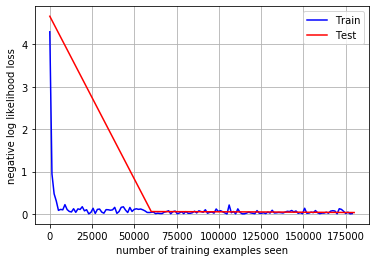

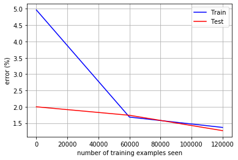

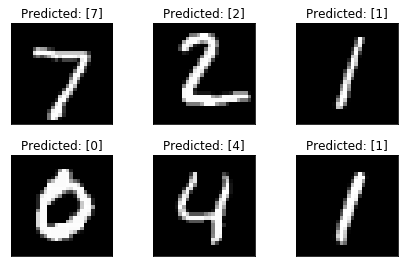

```python
    # lists for saving history
    train_losses = []
    train_counter = []
    test_losses = []
    test_counter = [i*len(train_loader.dataset) for i in range(epochs + 1)]
    train_errors = []
    test_errors = []
    error_counter = [i*len(train_loader.dataset) for i in range(epochs)]

    # test of randomly initialized model
    test(model, device, test_loader, losses=test_losses)

    # global training and testing loop
    for epoch in range(1, epochs + 1):
        train(model, device, train_loader, optimizer, epoch, losses=train_losses, counter=train_counter, errors=train_errors)
        test(model, device, test_loader, losses=test_losses, errors=test_errors)

    # plotting training history
    plot_graph(train_counter, train_losses, test_counter, test_losses, ylabel='negative log likelihood loss')
    plot_graph(error_counter, train_errors, error_counter, test_errors, ylabel='error (%)')

    # extract and plot random samples of data with predicted labels
    data, _, pred = predict_batch(model, device, test_loader)
    plot_data(data, pred, 'Predicted')

if __name__ == '__main__':
    main()
```